# Ask

# Analyze

## Total Count of casual riders vs. members.

SQL code to determine total values grouped by member_casual (total rides taken)

```
SELECT
    member_casual,
    COUNT(*) AS total_records,
    COUNT(ride_id) AS ride_id_count,
    COUNT(rideable_type) AS rideable_type_count,
    COUNT(started_at) AS started_at_count,
    COUNT(ended_at) AS ended_at_count,
    COUNT(start_station_name) AS start_station_name_count,
    COUNT(start_station_id) AS start_station_id_count,
    COUNT(end_station_name) AS end_station_name_count,
    COUNT(end_station_id) AS end_station_id_count,
    COUNT(start_lat) AS start_lat_count,
    COUNT(start_lng) AS start_lng_count,
    COUNT(end_lat) AS end_lat_count,
    COUNT(end_lng) AS end_lng_count
FROM `temptables-465123.case_study.cyclistic_2025`
GROUP BY member_casual;
```

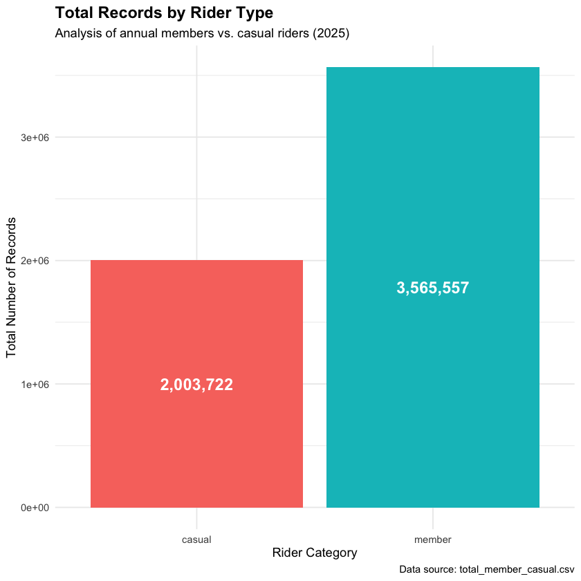

```r
#R Code
library(ggplot2)
library(readr)
library(scales) # Needed for comma formatting

# The file path has been changed from a Kaggle input path
# to a local or relative path (e.g., in the same directory as the notebook)
ggplot(read_csv("total_member_casual.csv",
                show_col_types = FALSE),
       aes(x = member_casual, y = total_records, fill = member_casual)) +
  geom_col() +
  geom_text(aes(label = scales::comma(total_records)),
            position = position_stack(vjust = 0.5),
            color = "white",
            fontface = "bold",
            size = 5) +
  labs(title = "Total Records by Rider Type",
       subtitle = "Analysis of annual members vs. casual riders (2025)",
       x = "Rider Category",
       y = "Total Number of Records",
       caption = "Data source: total_member_casual.csv") +
  theme_minimal() +
  theme(legend.position = "none",
        plot.title = element_text(face = "bold", size = 14))
```

## Preference for classic bikes vs. electric bikes.

SQL code to count rides taken grouped by member_id and ordered by rideable_type.

```
SELECT
    member_casual,
    rideable_type,
    COUNT(ride_id) AS total_rides
FROM
    `temptables-465123.case_study.cyclistic_2025`
GROUP BY
    member_casual,
    rideable_type
ORDER BY
    rideable_type;
```

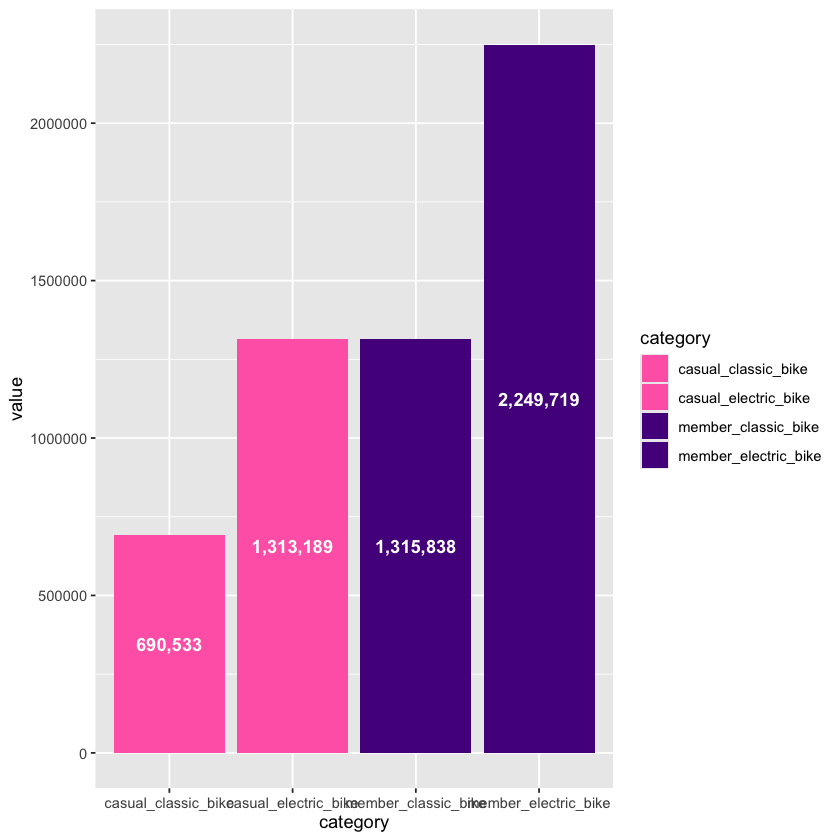

```r
# R Code
library(ggplot2)
library(tidyr)
library(dplyr)
library(readr)
suppressPackageStartupMessages(library(scales))

# The file path has been changed from a Kaggle input path
# to a local or relative path (e.g., in the same directory as the notebook)
df_long <- read_csv("./rideable_type2.csv",
                    show_col_types = FALSE) %>%
  pivot_longer(
    cols = c("casual_classic_bike", "casual_electric_bike",
             "member_classic_bike", "member_electric_bike"),
    names_to = "category",
    values_to = "value"
  )

ggplot(df_long, aes(x = category, y = value, fill = category)) +
  geom_col() +
  geom_text(aes(label = comma(value)),
            position = position_stack(vjust = 0.5),
            color = "white",
            fontface = "bold") +
  scale_fill_manual(values = c(
    "casual_classic_bike" = "hotpink",
    "casual_electric_bike" = "hotpink",
    "member_classic_bike" = "purple4",
    "member_electric_bike" = "purple4"
  ))
```

Take away: Both members and casual riders use electric bikes more than classic bikes.

## Average ride length.

In SQL calculate ride_length then calculate average ride_length grouped by member_casual and grouped by month

```
-- Step A: Add the new column
ALTER TABLE `temptables-465123.case_study.cyclistic_2025`
ADD COLUMN ride_length INT64;

-- Step B: Populate with the difference in seconds
UPDATE `temptables-465123.case_study.cyclistic_2025`
SET ride_length = TIMESTAMP_DIFF(ended_at, started_at, SECOND)
WHERE started_at IS NOT NULL AND ended_at IS NOT NULL;

SELECT
    member_casual,
    EXTRACT(MONTH FROM started_at) AS ride_month,
    AVG(ride_length) AS avg_ride_length_seconds
FROM `temptables-465123.case_study.cyclistic_2025`
WHERE ride_length IS NOT NULL
GROUP BY
    member_casual,
    ride_month
ORDER BY
    ride_month,
    member_casual;
```

SQL code to list average ride_length formatted by hh:mm:ss grouped by member_casual as rows and month as columns

```
SELECT
    member_casual,
    -- January
    TIME(TIMESTAMP_SECONDS(CAST(AVG(CASE WHEN EXTRACT(MONTH FROM started_at) = 1 THEN ride_length END) AS INT64))) AS Jan_Avg,
    -- February
    TIME(TIMESTAMP_SECONDS(CAST(AVG(CASE WHEN EXTRACT(MONTH FROM started_at) = 2 THEN ride_length END) AS INT64))) AS Feb_Avg,
    -- March
    TIME(TIMESTAMP_SECONDS(CAST(AVG(CASE WHEN EXTRACT(MONTH FROM started_at) = 3 THEN ride_length END) AS INT64))) AS Mar_Avg,
    -- April
    TIME(TIMESTAMP_SECONDS(CAST(AVG(CASE WHEN EXTRACT(MONTH FROM started_at) = 4 THEN ride_length END) AS INT64))) AS Apr_Avg,
    -- May
    TIME(TIMESTAMP_SECONDS(CAST(AVG(CASE WHEN EXTRACT(MONTH FROM started_at) = 5 THEN ride_length END) AS INT64))) AS May_Avg,
    -- June
    TIME(TIMESTAMP_SECONDS(CAST(AVG(CASE WHEN EXTRACT(MONTH FROM started_at) = 6 THEN ride_length END) AS INT64))) AS Jun_Avg,
    -- July
    TIME(TIMESTAMP_SECONDS(CAST(AVG(CASE WHEN EXTRACT(MONTH FROM started_at) = 7 THEN ride_length END) AS INT64))) AS Jul_Avg,
    -- August
    TIME(TIMESTAMP_SECONDS(CAST(AVG(CASE WHEN EXTRACT(MONTH FROM started_at) = 8 THEN ride_length END) AS INT64))) AS Aug_Avg,
    -- September
    TIME(TIMESTAMP_SECONDS(CAST(AVG(CASE WHEN EXTRACT(MONTH FROM started_at) = 9 THEN ride_length END) AS INT64))) AS Sep_Avg,
    -- October
    TIME(TIMESTAMP_SECONDS(CAST(AVG(CASE WHEN EXTRACT(MONTH FROM started_at) = 10 THEN ride_length END) AS INT64))) AS Oct_Avg,
    -- November
    TIME(TIMESTAMP_SECONDS(CAST(AVG(CASE WHEN EXTRACT(MONTH FROM started_at) = 11 THEN ride_length END) AS INT64))) AS Nov_Avg,
    -- December
    TIME(TIMESTAMP_SECONDS(CAST(AVG(CASE WHEN EXTRACT(MONTH FROM started_at) = 12 THEN ride_length END) AS INT64))) AS Dec_Avg
FROM `temptables-465123.case_study.cyclistic_2025`
WHERE ride_length IS NOT NULL
GROUP BY member_casual;
```

```r
#R Code
total_data <- read.csv("avg_ride_length_long.csv")

options(repr.matrix.max.rows = Inf, repr.matrix.max.cols = Inf)

total_data
```

A data.frame: 12 × 3

| month <chr> | member <chr> | casual <chr> |
| --- | --- | --- |
| Jan | 0:10:04 | 0:14:36 |
| Feb | 0:10:03 | 0:14:38 |
| Mar | 0:11:13 | 0:20:46 |
| Apr | 0:11:19 | 0:21:40 |
| May | 0:12:08 | 0:24:11 |
| Jun | 0:12:56 | 0:25:23 |
| Jul | 0:13:21 | 0:24:23 |
| Aug | 0:13:05 | 0:23:36 |
| Sep | 0:12:41 | 0:21:35 |
| Oct | 0:12:21 | 0:20:24 |
| Nov | 0:11:05 | 0:19:24 |
| Dec | 0:10:45 | 0:17:36 |

Take away: casual riders have longer average ride_length each month. Average ride_length for both members and casual riders increase during the months of March and begin to decline in July.

## Max ride length.

SQL code to calculate max ride_length grouped by member_casual and ordered by month

```
SELECT
    member_casual,
    -- Extracts the month number for grouping and ordering
    EXTRACT(MONTH FROM started_at) AS ride_month,
    -- Converts the max ride_length (in seconds) to HH:MM:SS format
    TIME(TIMESTAMP_SECONDS(MAX(ride_length))) AS max_ride_length_formatted
FROM
    `temptables-465123.case_study.cyclistic_2025`
GROUP BY
    member_casual,
    ride_month
ORDER BY
    ride_month;
```

```r
#R Code
total_data <- read.csv("max_ride_long.csv")

options(repr.matrix.max.rows = Inf, repr.matrix.max.cols = Inf)

total_data
```

A data.frame: 12 × 3

| month <chr> | casual_max_ride <chr> | member_max_ride <chr> |
| --- | --- | --- |
| Jan | 0:59:56 | 0:59:57 |
| Feb | 0:59:56 | 0:59:56 |
| Mar | 1:59:55 | 0:59:57 |
| Apr | 0:59:57 | 0:59:57 |
| May | 0:59:58 | 0:59:57 |
| Jun | 2:14:54 | 0:59:58 |
| Jul | 1:00:53 | 0:59:57 |
| Aug | 0:59:58 | 0:59:58 |
| Sep | 0:59:58 | 0:59:58 |
| Oct | 0:59:57 | 0:59:57 |
| Nov | 1:00:51 | 0:59:56 |
| Dec | 0:59:57 | 0:59:55 |

Take Away: casual riders had significantly longer max ride_length during March and June.

## Rides by Month and Day.

Total number of rides taken broken down by months and days of the week grouped by member_casual. Looking for seasonal trends. In SQL I added a column named “day_of_week” listing the correct day based on values in the “started_at” column. To calculate start day. I also added column named “month” that calculates the correct month based on values in the “started_at” column. To list the start month. Then I ran SQL code to give the total count of values in “ride_id” grouped by member_casual, day_of_week, and month.

```
SELECT
    member_casual,
    month,
    day_of_week,
    COUNT(ride_id) AS ride_count
FROM `temptables-465123.case_study.cyclistic_2025`
GROUP BY
    member_casual,
    month,
    day_of_week
ORDER BY
    member_casual;
```

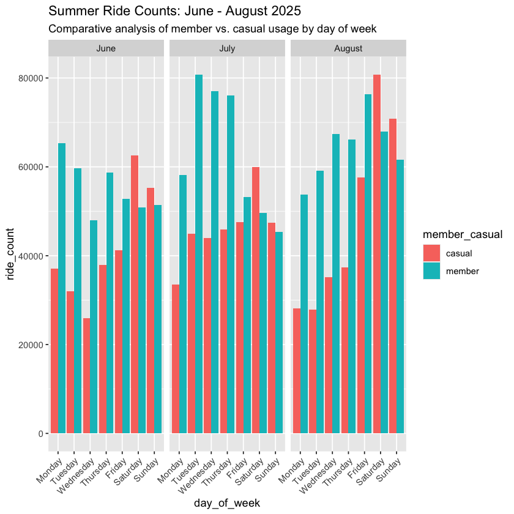

```r
#R Code
library(ggplot2)
library(dplyr)
library(readr)

# File path updated for a generic Jupyter environment
df_rides <- read_csv("ride_count.csv",
                     show_col_types = FALSE)

df_summer <- df_rides %>%
  filter(month %in% c("June", "July", "August")) %>%
  mutate(
    # Ensure months follow calendar order
    month = factor(month, levels = c("June", "July", "August")),
    # Ensure days of week follow calendar order
    day_of_week = factor(day_of_week, levels = c("Monday", "Tuesday", "Wednesday",
                                                  "Thursday", "Friday", "Saturday", "Sunday"))
  )

ggplot(df_summer, aes(x = day_of_week, y = ride_count, fill = member_casual)) +
  geom_col(position = "dodge") +
  facet_wrap(~ month) +
  labs(title = "Summer Ride Counts: June - August 2025",
       subtitle = "Comparative analysis of member vs. casual usage by day of week") +
  # --- Add this line to tilt x-axis labels by 45 degrees ---
  theme(axis.text.x = element_text(angle = 45, hjust = 1))
```

**IMPORTANT Take away:** the only time that casual riders have a higher ride count than members is on Saturday and Sunday during the months of June, July, August. The best time to market to casual riders is the weekends during the summer months.